# PARC T6.2.4 – Methodological Case Study: Frequentist & Bayesian Meta Analysis on Lead Exposure & IQ Loss

Modified

November 10, 2025

# 1 Introduction

This document describes the methodology of a frequentist and a Bayesian meta analysis on the effects of blood lead levels (BLL) in children (postnatal, concurrent) and their intellectual development (IQ). The results of these meta analyses will be used in Burden of Disease estimation within this methodological case study. The literature review of epidemiological studies was conducted by ANSES.

# 2 Harmonizing Effect Estimates

In order to pool the identified effect estimates, we need to transform some of them. Most of the studies transformed their blood lead level (BLL) data to a logarithmic scale in order to fulfill the assumption of a linear relationship between BLL (exposure) and IQ points (outcome) in their regression analyses. They did not always use the same log base. Some used log<sub>10</sub>, some ln (log<sub>e</sub>), and some used log<sub>2</sub>. Also, some of the included studies did not transform their BLL at all, so it is on a linear scale. ANSES standardized all estimates to linear increments of BLL, using the template published by [Rodriguez Barranco 2017](https://doi.org/10.1186/s12874-017-0322-8). The following visual tests will explain the rationale behind our decision to transform all effect estimates to a logarithmic scale.

## 2.1 Visualizing Transformations

Comparison of original beta coefficient from [Crump et al. 2013](https://doi.org/10.3109/10408444.2013.832726) (beta = -2.65, blue) for ln(BLL) to the transformed one (beta = -0.277, red) (now for linear BLL).

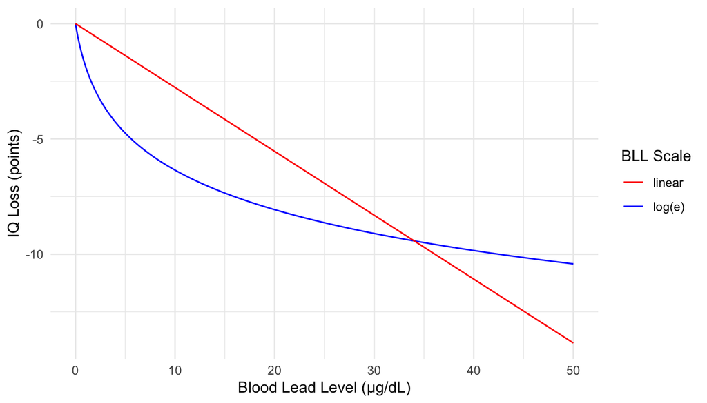

As visible in the graph, the effects of lower BLL would likely be underestimated in lower BLL ranges and overestimated in higher BLL ranges. Since today, BLL are often found to be very low (range in GerES V: approximately 0.04 to 4.5 µg/dL), the population health effects (Burden of Disease) of BLL would likely be underestimated. Therefore, effect estimates were transformed to ln(BLL) when necessary in order to harmonize them.

Formulas used to transform effect estimates to ln(BLL):
$$\beta_{ln} = \beta_{linear} \times C_{ref}\$$
$$\beta_{ln} = \frac{beta_{log_{2}}} {\ln(2)}\$$

$$\beta_{ln} = \frac{beta_{log_{10}}} {\ln(10)}\$$
Where:
$\beta_{ln}$ = harmonized beta coefficient (natural logarithm)
$\beta_{linear}$ = beta coefficient for linear BLL
$\beta_{log_2}$ = beta coefficient for log₂-transformed BLL
$\beta_{log_{10}}$ = beta coefficient for log₁₀-transformed BLL
$C_{ref}$ = reference concentration for linear transformation

In the following section, all three cases of transformations are visualized in order to check for validity.

### 2.1.1 Transformation: log<sub>10</sub>(BLL) to log<sub>e</sub>(BLL): [Dantzer et al. 2020](https://doi.org/10.1016/j.scitotenv.2019.134519)

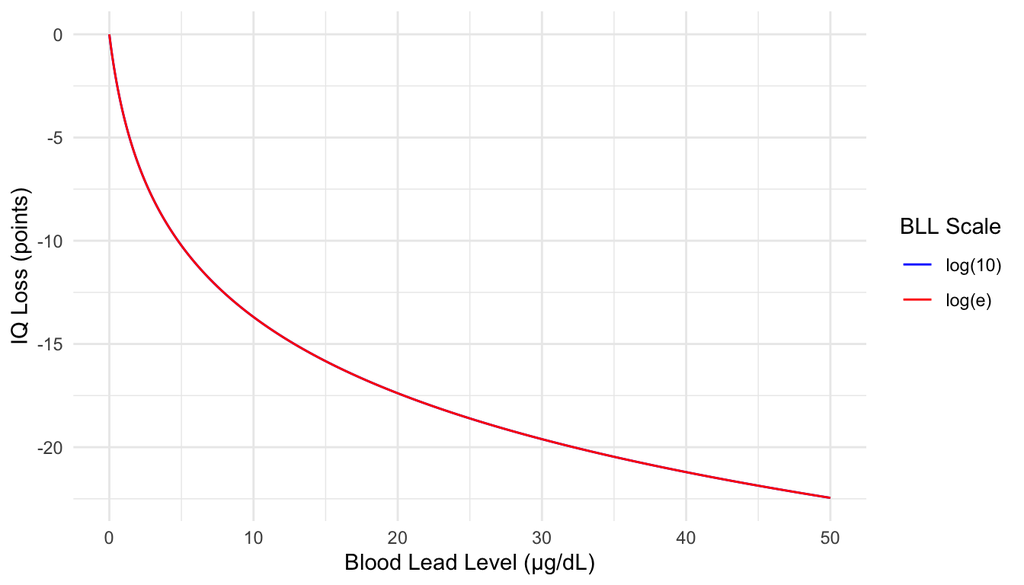

The transformation from log<sub>10</sub>(BLL) to log<sub>e</sub>(BLL) does not affect the exposure-response curve.

### 2.1.2 Transformation: log<sub>2</sub>(BLL) to log<sub>e</sub>(BLL): [Desrochers-Couture et al. 2018](https://doi.org/10.1016/j.envint.2018.10.043)

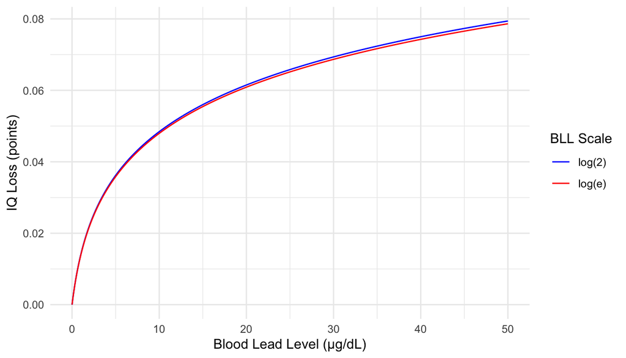

The transformation from log<sub>2</sub>(BLL) to log<sub>e</sub>(BLL) does not affect the exposure-response curve in the lower exposure ranges. Note: this study reported a small protective effect of lead exposure, this is why the curve is flipped.

### 2.1.3 Transformation: linear(BLL) to log<sub>e</sub>(BLL): [Iglesias et al. 2011](https://www.tandfonline.com/doi/10.1179/107735211799041841?url_ver=Z39.88-2003&rfr_id=ori:rid:crossref.org&rfr_dat=cr_pub%20%200pubmed)

In order to transform this estimate, we need to set a reference BLL ($C_{ref}$). 2.2 µg/dL was set in this transformation.

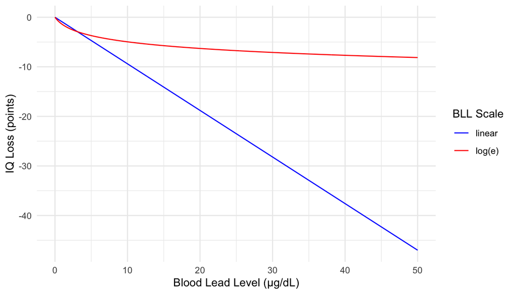

It appears that the transformed estimate does not accurately approximate the original estimate. For this meta analysis, we therefore decided to exclude all studies with estimates for untransformed BLL data.

These are the final studies and transformed effect estimates:

[output not shown]

# 3 Results

## 3.1 Analysis 1.1: Bayesian

Setting weakly informative priors:

```r
library(brms)

priors <- c(prior(normal(-1, 2), class = Intercept),
            prior(normal(0, 2), class = sd, lb = 0))
```

Fitting Bayesian multilevel random effects model using brms:

```r
library(brms)

m.brm_analysis1 <- brm(
  beta_ln|se(se_beta_ln) ~ 1 + (1|author_year),
  data = data_anaylsis1,
  prior = priors,
  save_pars = save_pars(all = TRUE),
  chains = 4,
  iter = 4000)
```

```
 Family: gaussian
  Links: mu = identity; sigma = identity
Formula: beta_ln | se(se_beta_ln) ~ 1 + (1 | author_year)
   Data: data_anaylsis1 (Number of observations: 10)
  Draws: 4 chains, each with iter = 4000; warmup = 2000; thin = 1;
         total post-warmup draws = 8000

Multilevel Hyperparameters:
~author_year (Number of levels: 10)
              Estimate Est.Error l-95% CI u-95% CI Rhat Bulk_ESS Tail_ESS
sd(Intercept)     1.80      0.57     0.92     3.12 1.00     2101     3306

Regression Coefficients:
          Estimate Est.Error l-95% CI u-95% CI Rhat Bulk_ESS Tail_ESS
Intercept    -1.72      0.65    -3.09    -0.53 1.00     1990     2989

Further Distributional Parameters:
      Estimate Est.Error l-95% CI u-95% CI Rhat Bulk_ESS Tail_ESS
sigma     0.00      0.00     0.00     0.00   NA       NA       NA

Draws were sampled using sampling(NUTS). For each parameter, Bulk_ESS
and Tail_ESS are effective sample size measures, and Rhat is the potential
scale reduction factor on split chains (at convergence, Rhat = 1).
```

Forest plot:

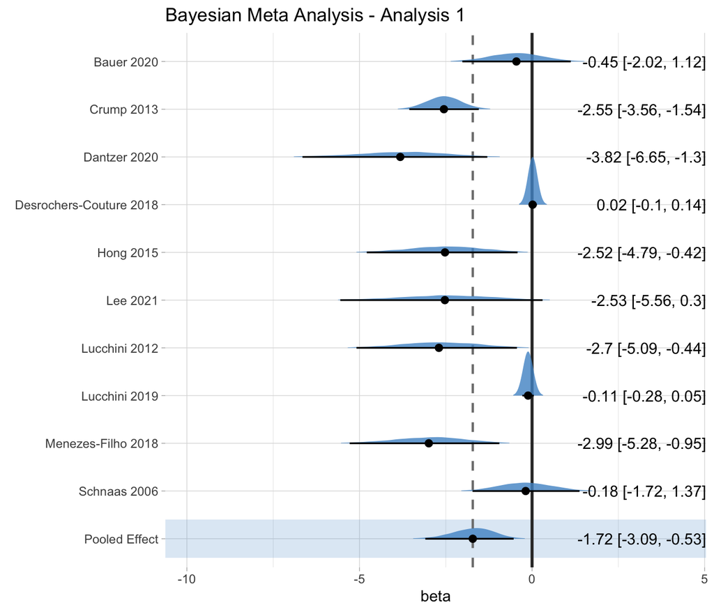

## 3.2 Analysis 1.2: Frequentist

Fitting frequentist random effects meta analysis using metafor:

```r
library(metafor)

rma_model1 <- rma(yi = beta_ln,
                 sei = se_beta_ln,
                 data = data_anaylsis1,
                 method = "REML")
```

```
Random-Effects Model (k = 10; tau^2 estimator: REML)

  logLik  deviance       AIC       BIC      AICc
-19.4091   38.8182   42.8182   43.2126   44.8182

tau^2 (estimated amount of total heterogeneity): 3.0078 (SE = 1.9033)
tau (square root of estimated tau^2 value):      1.7343
I^2 (total heterogeneity / total variability):   98.49%
H^2 (total variability / sampling variability):  66.30

Test for Heterogeneity:
Q(df = 9) = 59.6216, p-val < .0001

Model Results:

estimate      se     zval    pval    ci.lb    ci.ub
 -1.8277  0.6434  -2.8407  0.0045  -3.0887  -0.5666  **

---
Signif. codes:  0 '***' 0.001 '**' 0.01 '*' 0.05 '.' 0.1 ' ' 1
```

Forest plot:

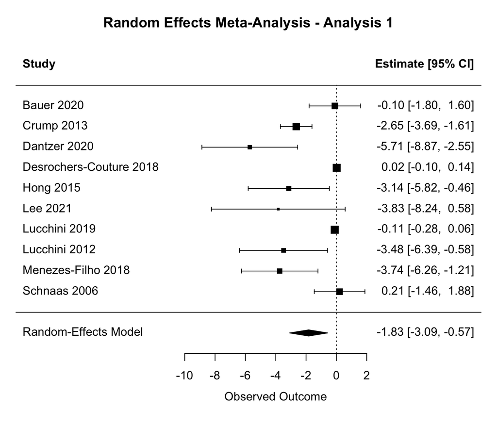

## 3.3 Analysis 2.1: Bayesian

Now including Earl 2016 and Roy 2013.

Fitting Bayesian multilevel random effects model using brms and the same priors as in analysis 1.1:

```r
library(brms)

m.brm_analysis2 <- brm(
  beta_ln|se(se_beta_ln) ~ 1 + (1|author_year),
  data = data_anaylsis2,
  prior = priors,
  save_pars = save_pars(all = TRUE),
  chains = 4,
  iter = 4000)
```

```
 Family: gaussian
  Links: mu = identity; sigma = identity
Formula: beta_ln | se(se_beta_ln) ~ 1 + (1 | author_year)
   Data: data_anaylsis2 (Number of observations: 12)
  Draws: 4 chains, each with iter = 4000; warmup = 2000; thin = 1;
         total post-warmup draws = 8000

Multilevel Hyperparameters:
~author_year (Number of levels: 12)
              Estimate Est.Error l-95% CI u-95% CI Rhat Bulk_ESS Tail_ESS
sd(Intercept)     1.94      0.54     1.06     3.22 1.00     2037     3857

Regression Coefficients:
          Estimate Est.Error l-95% CI u-95% CI Rhat Bulk_ESS Tail_ESS
Intercept    -2.10      0.65    -3.41    -0.85 1.00     1975     2994

Further Distributional Parameters:
      Estimate Est.Error l-95% CI u-95% CI Rhat Bulk_ESS Tail_ESS
sigma     0.00      0.00     0.00     0.00   NA       NA       NA

Draws were sampled using sampling(NUTS). For each parameter, Bulk_ESS
and Tail_ESS are effective sample size measures, and Rhat is the potential
scale reduction factor on split chains (at convergence, Rhat = 1).
```

Forest plot:

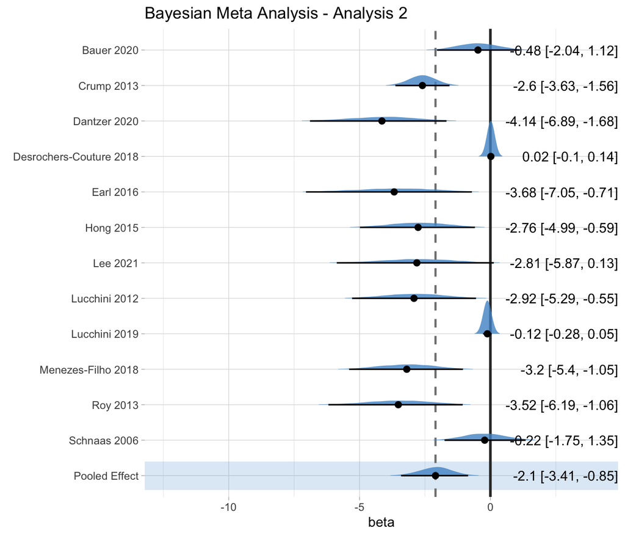

## 3.4 Analysis 2.2: Frequentist

Fitting frequentist random effects meta analysis using metafor:

```r
rma_model2 <- rma(yi = beta_ln,
                 sei = se_beta_ln,
                 data = data_anaylsis2,
                 method = "REML")
```

```
Random-Effects Model (k = 12; tau^2 estimator: REML)

  logLik  deviance       AIC       BIC      AICc
-24.6351   49.2702   53.2702   54.0660   54.7702

tau^2 (estimated amount of total heterogeneity): 3.6003 (SE = 2.1009)
tau (square root of estimated tau^2 value):      1.8974
I^2 (total heterogeneity / total variability):   98.47%
H^2 (total variability / sampling variability):  65.23

Test for Heterogeneity:
Q(df = 11) = 74.2470, p-val < .0001

Model Results:

estimate      se     zval    pval    ci.lb    ci.ub
 -2.2617  0.6495  -3.4826  0.0005  -3.5346  -0.9888  ***

---
Signif. codes:  0 '***' 0.001 '**' 0.01 '*' 0.05 '.' 0.1 ' ' 1
```

Forest plot:

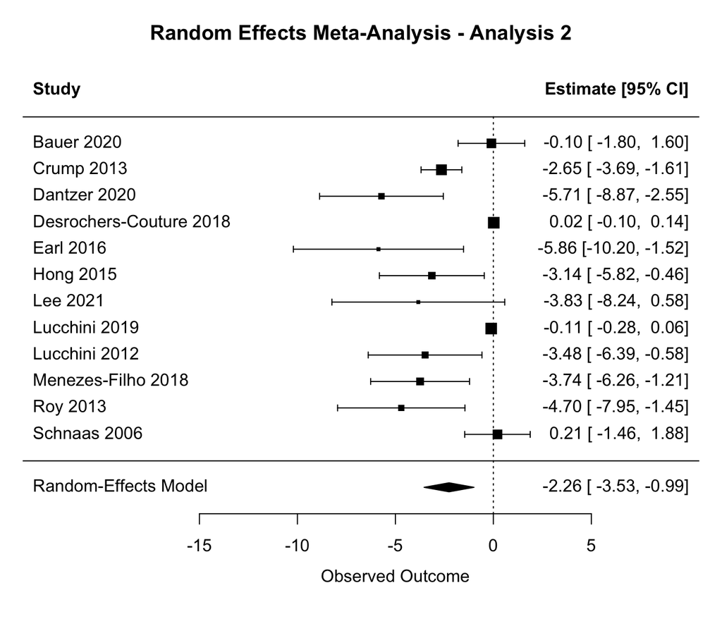

# 4 Comparing results

Comparing the four results:

| Model | Beta | SE |
| --- | --- | --- |
| Bayesian, n = 10 included studies (Analysis 1) | -1.72 | 0.65 |
| Frequentist, n = 10 included studies (Analysis 1) | -1.83 | 0.64 |
| Bayesian, n = 12 included studies (Analysis 2) | -2.1 | 0.65 |
| Frequentist, n = 12 included studies (Analysis 2) | -2.26 | 0.65 |

In both analyses, the mean pooled effect resulting from the Bayesian meta analysis is smaller than from the frequentist approach. This might be due to a process called shrinkage: The model estimates ‘true’ effect sizes for each study and if it detects outliers, they will be pulled towards the overall effect. This is an advantage of the Bayesian approach, particularly when pooling a small number of studies. The model is less sensitive to outliers than frequentist models.

One advantage of the Bayesian approach is that the full posterior distribution of the pooled effect can be used directly in EBD assessments via Monte Carlo simulation. These are the posterior distributions of beta in both analyses:

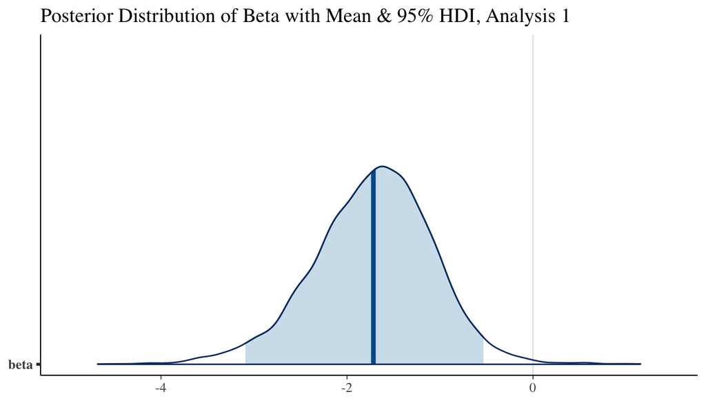

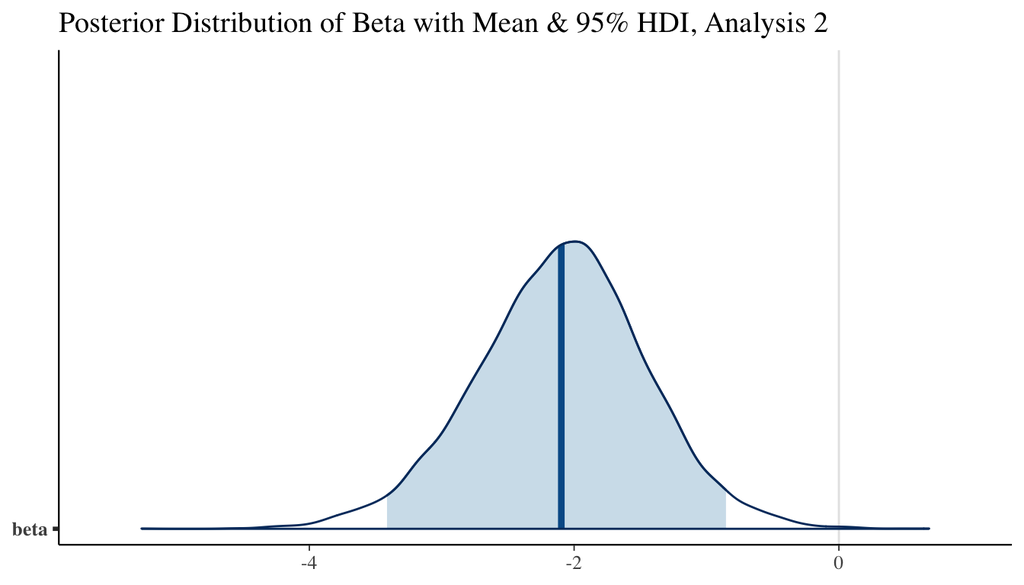

# 5 References

Bauer JA, Devick KL, Bobb JF, Coull BA, Bellinger D, Benedetti C, Cagna G, Fedrighi C, Guazzetti S, Oppini M, et al. Associations of a Metal Mixture Measured in Multiple Biomarkers with IQ: Evidence from Italian Adolescents Living near Ferroalloy Industry. Environmental Health Perspectives 2020, 128(9):097002.

Cao Y, Chen A, Jones RL, Radcliffe J, Caldwell KL, Dietrich KN, Rogan WJ. Does background postnatal methyl mercury exposure in toddlers affect cognition and behavior? NeuroToxicology 2010, 31(1):1-9.

Chen A, Dietrich KN, Ware JH, Radcliffe J, Rogan WJ. IQ and Blood Lead from 2 to 7 Years of Age: Are the Effects in Older Children the Residual of High Blood Lead Concentrations in 2-Year-Olds? Environmental Health Perspectives 2005, 113(5):597-601.

Crump KS, Van Landingham C, Bowers TS, Cahoy D, Chandalia JK. A statistical reevaluation of the data used in the Lanphear et al. () pooled-analysis that related low levels of blood lead to intellectual deficits in children. Critical Reviews in Toxicology 2013, 43(9):785-99.

Dantzer J, Ryan P, Yolton K, Parsons PJ, Palmer CD, Cecil K, Unrine JM. A comparison of blood and toenails as biomarkers of children’s exposure to lead and their correlation with cognitive function. Science of The Total Environment 2020, 700:134519.

Desrochers-Couture M, Oulhote Y, Arbuckle TE, Fraser WD, Séguin JR, Ouellet E, Forget-Dubois N, Ayotte P, Boivin M, Lanphear BP, et al. Prenatal, concurrent, and sex-specific associations between blood lead concentrations and IQ in preschool Canadian children. Environment International 2018, 121:1235-42.

Earl R, Burns N, Nettelbeck T, Baghurst P. Low‐level environmental lead exposure still negatively associated with children’s cognitive abilities. Australian Journal of Psychology 2016, 68(2):98-106.

Halabicky OM, Pinto-Martin JA, Compton P, Liu J. Low level lead exposure in early childhood and parental education on adolescent IQ and working memory: a cohort study. Journal of Exposure Science & Environmental Epidemiology 2023, 33(2):168-76.

Hong S-B, Im M-H, Kim J-W, Park E-J, Shin M-S, Kim B-N, Yoo H-J, Cho I-H, Bhang S-Y, Hong Y-C, et al. Environmental Lead Exposure and Attention Deficit/Hyperactivity Disorder Symptom Domains in a Community Sample of South Korean School-Age Children. Environmental Health Perspectives 2015, 123(3):271-6.

Hornung RW, Lanphear BP, Dietrich KN. Age of Greatest Susceptibility to Childhood Lead Exposure: A New Statistical Approach. Environmental Health Perspectives 2009, 117(8):1309-12.

Iglesias V, Steenland K, Maisonet M, Pino P. Exposure to Lead from a Storage Site Associated with Intellectual Impairment in Chilean Children Living Nearby. International Journal of Occupational and Environmental Health 2011, 17(4):314-21.

Lanphear BP, Hornung R, Khoury J, Yolton K, Baghurst P, Bellinger DC, Canfield RL, Dietrich KN, Bornschein R, Greene T, et al. Low-Level Environmental Lead Exposure and Children’s Intellectual Function: An International Pooled Analysis. Environmental Health Perspectives 2005, 113(7):894-9.

Lee K-S, Kim K-N, Ahn YD, Choi Y-J, Cho J, Jang Y, Lim Y-H, Kim JI, Shin CH, Lee YA, et al. Prenatal and postnatal exposures to four metals mixture and IQ in 6-year-old children: A prospective cohort study in South Korea. Environment International 2021, 157:106798.

Lucchini RG, Guazzetti S, Renzetti S, Conversano M, Cagna G, Fedrighi C, Giorgino A, Peli M, Placidi D, Zoni S, et al. Neurocognitive impact of metal exposure and social stressors among schoolchildren in Taranto, Italy. Environmental Health 2019, 18(1):67.

Lucchini RG, Zoni S, Guazzetti S, Bontempi E, Micheletti S, Broberg K, Parrinello G, Smith DR. Inverse association of intellectual function with very low blood lead but not with manganese exposure in Italian adolescents. Environmental Research 2012, 118:65-71.

Menezes-Filho JA, Carvalho CF, Rodrigues JLG, Araújo CFS, Dos Santos NR, Lima CS, Bandeira MJ, Marques BLdS, Anjos ALS, Bah HAF, et al. Environmental Co-Exposure to Lead and Manganese and Intellectual Deficit in School-Aged Children. International Journal of Environmental Research and Public Health 2018, 15(11):2418.

Rodríguez-Barranco M, Tobías A, Redondo D, Molina-Portillo E, Sánchez MJ. Standardizing effect size from linear regression models with log-transformed variables for meta-analysis. BMC Medical Research Methodology 2017, 17(1):44.

Min MO, Singer LT, Kirchner HL, Minnes S, Short E, Hussain Z, Nelson S. Cognitive development and low-level lead exposure in poly-drug exposed children. Neurotoxicology and Teratology 2009, 31(4):225-31.

Roy A, Ettinger AS, Hu H, Bellinger D, Schwartz J, Modali R, Wright RO, Palaniappan K, Balakrishnan K. Effect modification by transferrin C2 polymorphism on lead exposure, hemoglobin levels, and IQ. NeuroToxicology 2013, 38:17-22.

Schnaas L, Rothenberg Stephen J, Flores M-F, Martinez S, Hernandez C, Osorio E, Velasco Silvia R, Perroni E. Reduced Intellectual Development in Children with Prenatal Lead Exposure. Environmental Health Perspectives 2006, 114(5):791-7.

Wang Y, Wang Y, Yan C. Gender differences in trace element exposures with cognitive abilities of school-aged children: a cohort study in Wujiang city, China. Environmental Science and Pollution Research 2022, 29(43):64807-21.